# Relatório IC

Fernanda Buzza Alves Barros

## INTRODUÇÃO

Problemas de dados faltantes em pesquisa são recorrentes em bancos de dados. Para a solução desses problemas existem vários métodos que podem ser utilizados. Entretanto, todos os métodos possuem uma questão principal: como inferir os valores não observados?

Para a resposta dessa pergunta, temos que o ideal seria ter os dados, porém na falta deles temos que utilizar o método que melhor se ajusta a distribuição dos dados.

Nessa pesquisa utilizaremos o método proposto por Rubin (1987), Van Buuren e Groothuis-Oudshoorn (2011), que é conhecido como Imputação Múltipla.

## METODOLOGIA

#2.1) Predictive Mean Matching (pmm)

##3) RESULTADOS

#3.1) Banco de dados

Para realizar a imputação dos dados utilizamos o banco de dados *US Term Life insurance* do pacote *CASdatasets* disponível no software R. As imputações e os resultados foram obtidos utilizando esse mesmo software estatístico. O banco de dados possui 18 variáveis com 500 observações, como pode ser visto abaixo.

```
## 'data.frame':    500 obs. of  18 variables:
##  $ Gender         : int  1 1 1 1 1 1 0 1 1 1 ...
##  $ Age            : int  30 50 39 43 61 34 75 29 35 70 ...
##  $ MarStat        : int  1 1 1 1 1 2 0 1 2 1 ...
##  $ Education      : int  16 9 16 17 15 11 8 16 4 17 ...
##  $ Ethnicity      : int  3 3 1 1 1 2 1 1 3 1 ...
##  $ SmarStat       : int  2 1 2 1 2 1 0 2 1 2 ...
##  $ Sgender        : int  2 2 2 2 2 2 0 2 2 2 ...
##  $ Sage           : int  27 47 38 35 59 31 0 31 45 74 ...
##  $ Seducation     : int  16 8 16 14 12 14 0 17 9 16 ...
##  $ NumHH          : int  3 3 5 4 2 4 1 3 2 2 ...
##  $ Income         : int  43000 12000 120000 40000 25000 28000 2500 100000 20000 101000 ...
##  $ TotIncome      : int  43000 0 90000 40000 1020000 0 0 84000 0 6510000 ...
##  $ Charity        : int  0 0 500 0 500 0 0 0 0 284000 ...
##  $ Face           : int  20000 130000 1500000 50000 0 220000 0 600000 0 0 ...
##  $ FaceCVLifePol  : int  0 0 0 75000 7000000 0 14000 0 0 2350000 ...
##  $ CashCVLifePol  : int  0 0 0 0 300000 0 5000 0 0 0 ...
##  $ BorrowCVLifePol: int  0 0 0 5 5 0 5 0 0 5 ...
##  $ NetValue       : int  0 0 0 0 0 0 0 0 0 0 ...
```

Porém selecionamos as seguintes variáveis: Gênero (gênero do entrevistado); Idade (idade do entrevistado); Estado Civil (estado civil do entrevistado); Escolaridade (número de anos de escolaridade do entrevistado); Etnia (etnia); Renda (renda anual da família).

O banco de dados não possui dados faltantes, portanto para avaliar a Renda (variável de interesse) foi necessário gerar os dados faltantes. Sendo assim utilizamos uma distribuição binomial com probabilidade de sucesso de 0.2 para a criar dos dados faltantes na variável Renda, fixando a semente em set.seed(0).

Primeiras observações do banco de dados original:

|  | Gender | Age | MarStat | Education | Ethnicity | Income |
| --- | --- | --- | --- | --- | --- | --- |
| 1 | 1 | 30 | 1 | 16 | 3 | 43000 |
| 2 | 1 | 50 | 1 | 9 | 3 | 12000 |
| 3 | 1 | 39 | 1 | 16 | 1 | 120000 |
| 4 | 1 | 43 | 1 | 17 | 1 | 40000 |
| 5 | 1 | 61 | 1 | 15 | 1 | 25000 |
| 6 | 1 | 34 | 2 | 11 | 2 | 28000 |

Primeiras observações do banco de dados com dados faltantes na variável Renda:

|  | Gender | Age | MarStat | Education | Ethnicity | Income |
| --- | --- | --- | --- | --- | --- | --- |
| 1 | 1 | 30 | 1 | 16 | 3 | NA |
| 2 | 1 | 50 | 1 | 9 | 3 | 12000 |
| 3 | 1 | 39 | 1 | 16 | 1 | 120000 |
| 4 | 1 | 43 | 1 | 17 | 1 | 40000 |
| 5 | 1 | 61 | 1 | 15 | 1 | NA |
| 6 | 1 | 34 | 2 | 11 | 2 | 28000 |

#3.2) Análise Descritiva

Analisaremos as relações entre as variáveis selecionadas do banco de dados original. O principal objetivo é verificar os possíveis questionamentos sobre a Renda a partir das outras variáveis. Temos interesse em responder as seguintes perguntas: - Como está distribuída a variável Renda. - Qual é a relação entre a Renda e o Gênero. - Com maiores anos de escolaridade há aumento da renda. - O estado civil tem influência na renda. - Avaliar a relação entre a etnia e a renda.

Primeiramente iremos analisar algumas das principais informações das variáveis, como: mínimo, máximo, média, mediana e quantis. Assim obtemos a tabela abaixo:

Para a variável Idade temos:

```
##    Min. 1st Qu.  Median    Mean 3rd Qu.    Max.
##   20.00   37.00   47.00   47.16   58.00   85.00
```

Assim para a pesquisa a idade máxima é 85 anos e a idade mínima é 20 anos. A média é 47,16 anos e a mediana 47 anos. O primeiro quantil é de 37 anos e o terceiro é de 58 anos.

Analisando a variável Anos de Escolaridade temos:

```
##    Min. 1st Qu.  Median    Mean 3rd Qu.    Max.
##    2.00   12.00   14.00   14.06   16.00   17.00
```

O mínimo de anos de escolaridade é 2 anos e o máximo é 17 anos. A mediana e a média são 14 anos e 14,06 anos, respectivamente. E o primeiro quantil é 12 anos e o terceiro quantil é 16 anos.

Analisando a variável Renda obtemos:

```
##     Min.  1st Qu.   Median     Mean  3rd Qu.     Max.
##      260    28000    54000   321022   106000 75000000
```

Essa variável possui como renda mínima 260 dólares e renda máxima 75.000.000 dólares. A mediana e a média são 54.000 dólares e 321.022 doláres, respectivamente. E o primeiro e terceiro quantis são 28.000 dólares e 106.000 dólares.

Por fim, avaliando as variáveis Estado Civil, Gênero e Etnia temos:

```
## , , MarStat = 0
##
##       Ethnicity
## Gender   1   2   3   7 Sum
##    0    51  24   5   3  83
##    1    37  12   2   2  53
##    Sum  88  36   7   5 136
##
## , , MarStat = 1
##
##       Ethnicity
## Gender   1   2   3   7 Sum
##    0     2   1   0   0   3
##    1   260  25  26  19 330
##    Sum 262  26  26  19 333
##
## , , MarStat = 2
##
##       Ethnicity
## Gender   1   2   3   7 Sum
##    0     0   1   0   0   1
##    1    15   7   7   1  30
##    Sum  15   8   7   1  31
##
## , , MarStat = Sum
##
##       Ethnicity
## Gender   1   2   3   7 Sum
##    0    53  26   5   3  87
##    1   312  44  35  22 413
##    Sum 365  70  40  25 500
```

Sendo assim a pesquisa possui 87 respondentes do sexo feminino e 413 respondentes do sexo masculino.

## Renda e Gênero

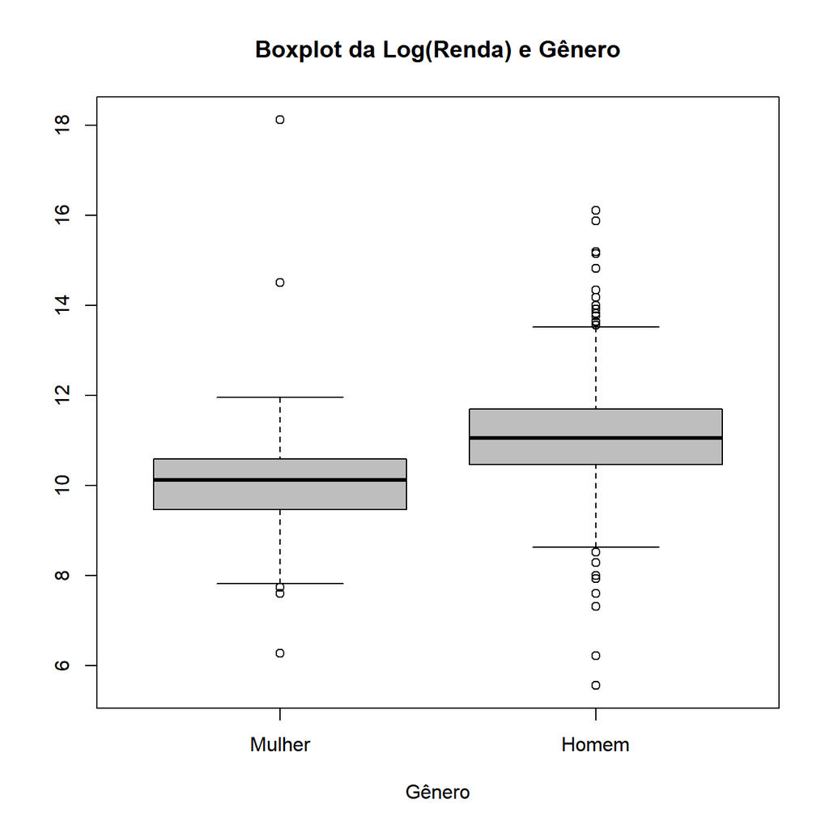

Ao plotarmos os boxplots da Log(Renda) e o Gênero vemos a relação entre os valores da renda dos homens comparados com os das mulheres. Nesse caso os homens possuem maiores valores de renda do que as mulheres.

## Renda e Anos de Escolaridade

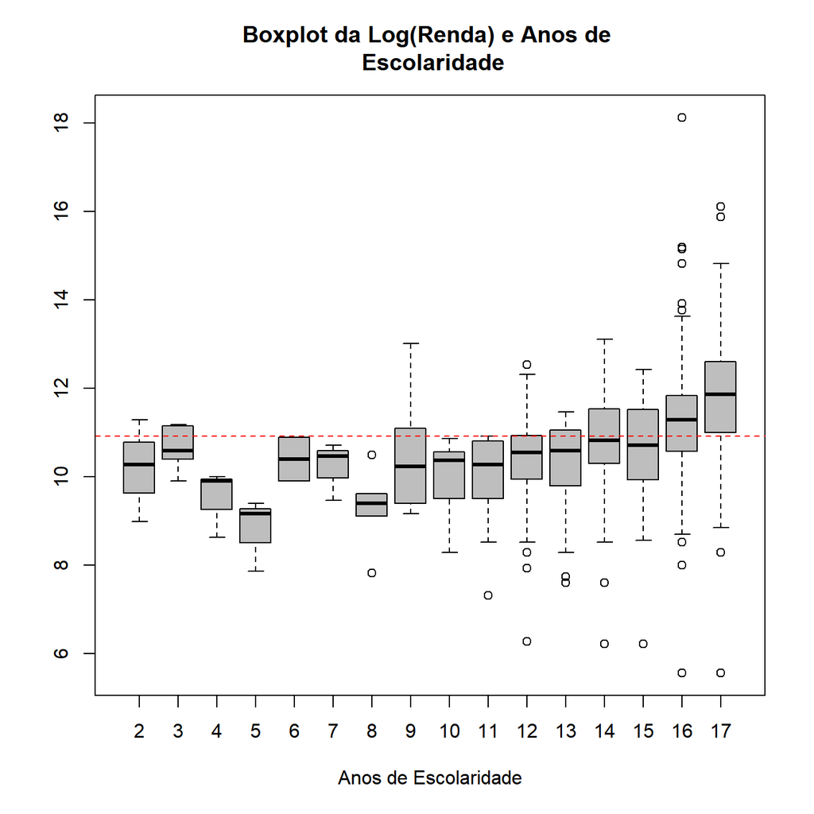

Ao analisar o efeito na quantidade de Anos de Escolaridade e a Renda, percebemos um crescimento na quantidade ganha de renda de acordo com os anos de escolaridade. Observamos que com a inclusão da reta pontilhada em vermelho, que representa a média da variável Log(Renda), a possibilidade de determinar os anos de escolaridade que estão acima da média de valores ganhos de renda. Entre os anos de escolaridade de 2 a 8 anos não percebemos uma relação crescente, sendo que há uma queda em 4, 5 e 8 anos de escolaridade, que pode ser devido a quantidade de entrevistados desses grupos representados no banco de dados; o que pode ser verificado na tabela abaixo:

```
## Education
##   2   3   4   5   6   7   8   9  10  11  12  13  14  15  16  17 Sum
##   3   5   3   3   2   3   5   6   7  15 101  31  68  16 130 102 500
```

## Renda e Estado Civil

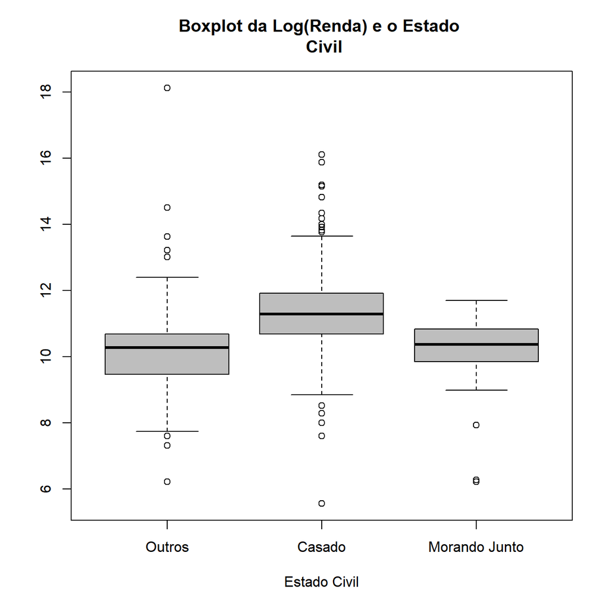

Para analisar a relação entre o Estado Civil e a Log(Renda) percebemos que as pessoas casadas possuem uma renda maior, quando comparado com os outros grupos apresentados pelo banco de dados.

## Renda e Etnia

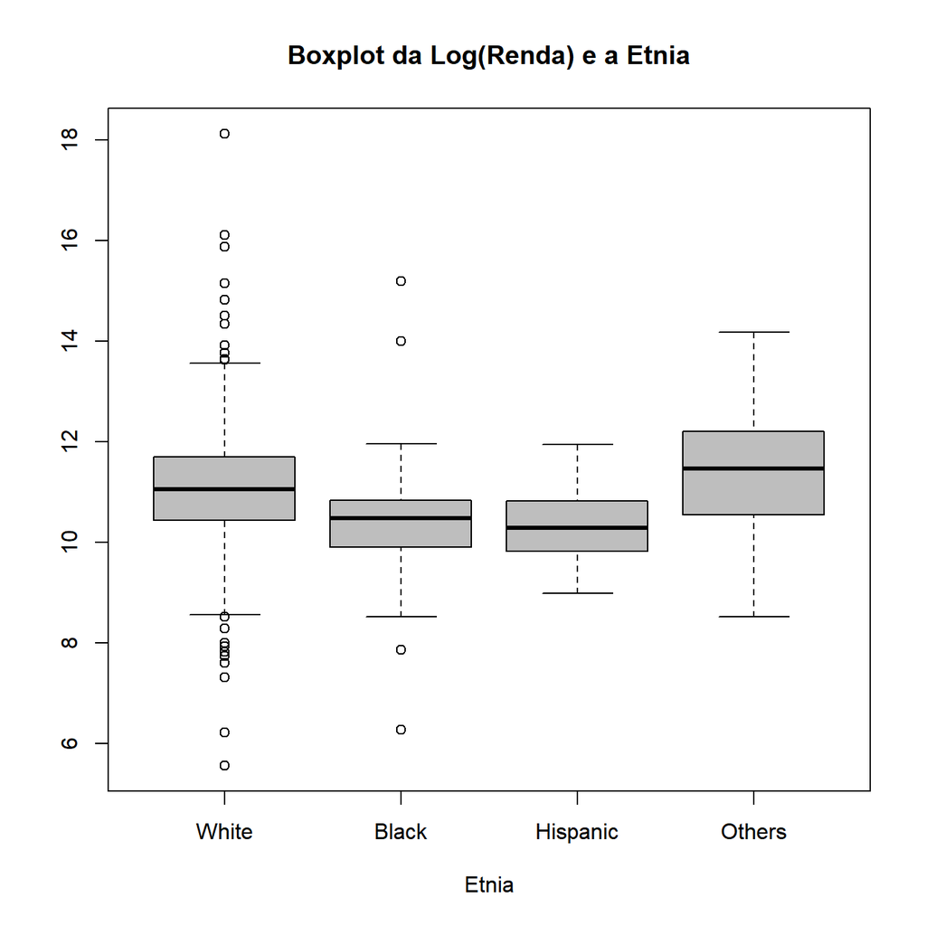

Para avaliar a relação entre a Etnia e a Log(Renda) observamos maiores valores de renda para o grupo white e o others, sendo que os grupos black e hispanic apresentam similaridades nos valores de renda.

#3.3) Imputação

Abaixo temos o output da função de imputação com as principais informações.

```
## Class: mids
## Number of multiple imputations:  5
## Imputation methods:
##    Gender       Age   MarStat Education Ethnicity    Income
##        ""        ""        ""        ""        ""     "pmm"
## PredictorMatrix:
##           Gender Age MarStat Education Ethnicity Income
## Gender         0   0       0         0         0      0
## Age            0   0       0         0         0      0
## MarStat        0   0       0         0         0      0
## Education      0   0       0         0         0      0
## Ethnicity      0   0       0         0         0      0
## Income         1   1       1         1         1      0
```

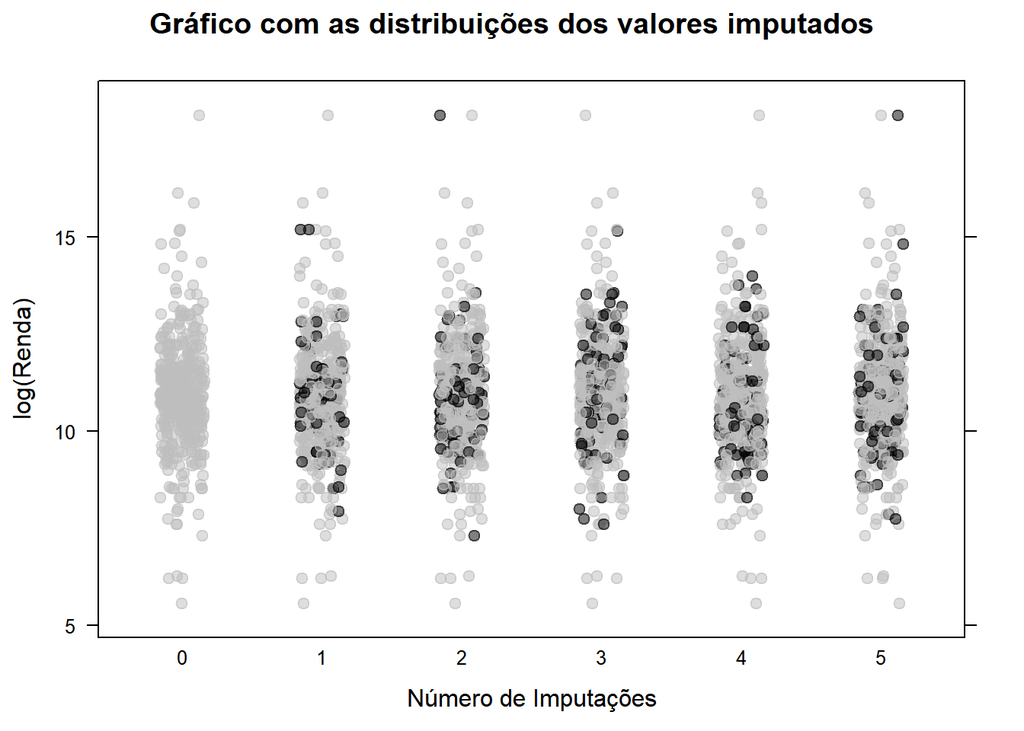

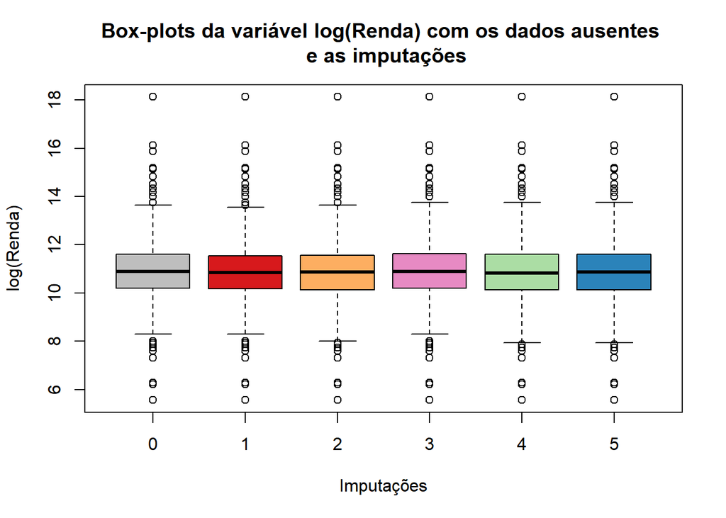

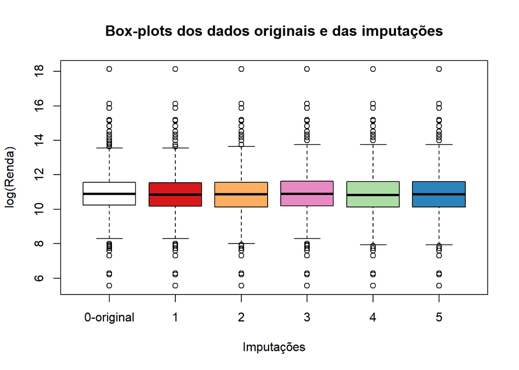

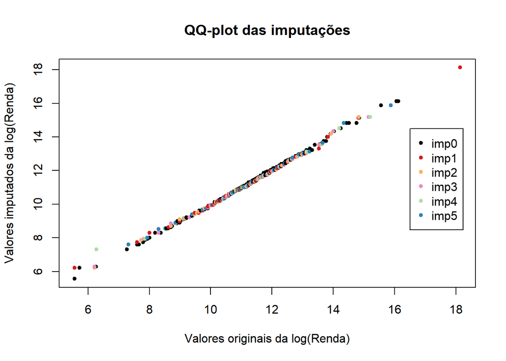

##5) REFERÊNCIAS BIBLIOGRÁFICAS

Rubin (1987)

Van Buuren, S., Groothuis-Oudshoorn, K. (2011). mice: Multivariate Imputation by Chained Equations in R. Journal of Statistical Software, 45(3), 1-67. [linked phrase](http://www.jstatsoft.org/v45/i03/)

Morris TP, White IR, Royston P (2015). Tuning multiple imputation by predictive mean matching and local residual draws. BMC Med Res Methodol. ;14:75.

Frees, E.W. (2011). Regression Modeling with Actuarial and Financial Applications, Cambridge University Press.